**Modern CNNs**

By Prof. Seungchul Lee  
http://iai.postech.ac.kr/  
Industrial AI Lab at POSTECH

Table of Contents

# 1. ImageNet

- Human performance = 5.1%

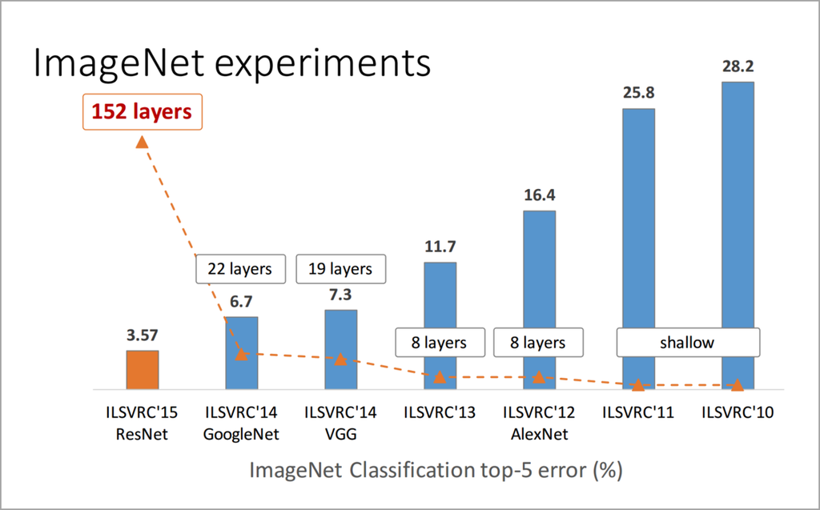

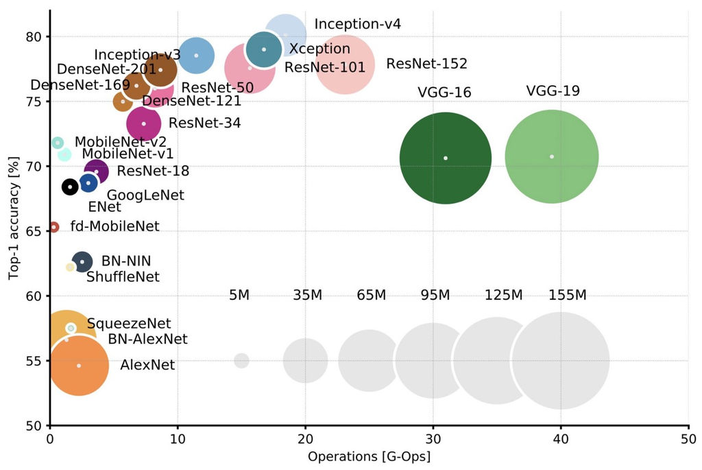

## 1.1. LeNet

- CNN = Convolutional Neural Networks = ConvNet
- LeCun, Y., Bottou, L., Bengio, Y., and Haffner, P. (1998). Gradient-based learning applied to document recognition.
- All are still the basic components of modern ConvNets!

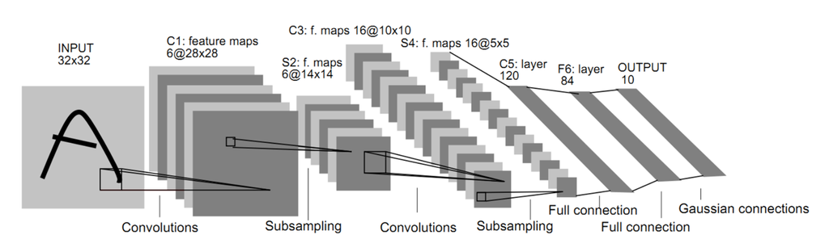

## 1.2. AlexNet

- Simplified version of Krizhevsky, Alex, Sutskever, and Hinton. "Imagenet classification with deep convolutional neural networks." NIPS 2012
- LeNet-style backbone, plus:
  - ReLU [Nair & Hinton 2010]
    - RevoLUtion of deep learning
    - Accelerate training
  - Dropout [Hinton et al 2012]
    - In-network ensembling
    - Reduce overfitting
  - Data augmentation
    - Label-preserving transformation
    - Reduce overfitting

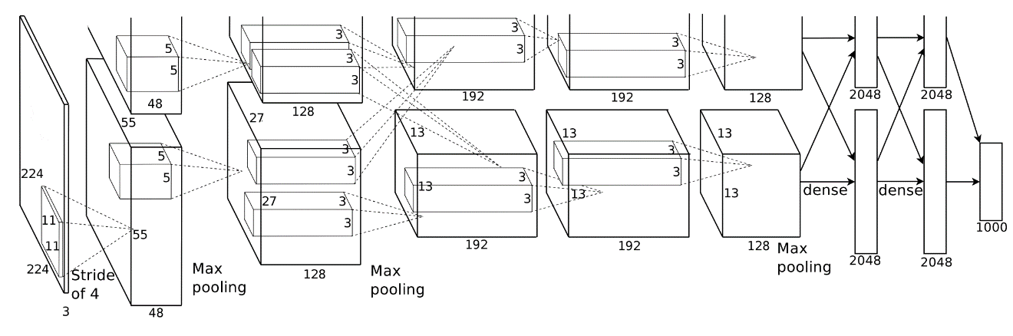

## 1.3. VGG-16/19

- Simonyan, Karen, and Zisserman. "Very deep convolutional networks for large-scale image recognition." (2014)
- Simply “Very Deep”!
  - Modularized design
    - 3x3 Conv as the module
    - Stack the same module
    - Same computation for each module
  - Stage-wise training
    - VGG-11 → VGG-13 → VGG-16
    - We need a better initialization…

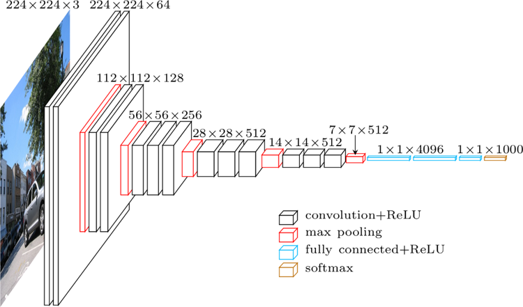

## 1.4. GoogleNet/Inception

- Multiple branches
  - e.g., 1x1, 3x3, 5x5, pool
- Shortcuts
  - stand-alone 1x1, merged by concat.
- Bottleneck
  - Reduce dim by 1x1 before expensive 3x3/5x5 conv

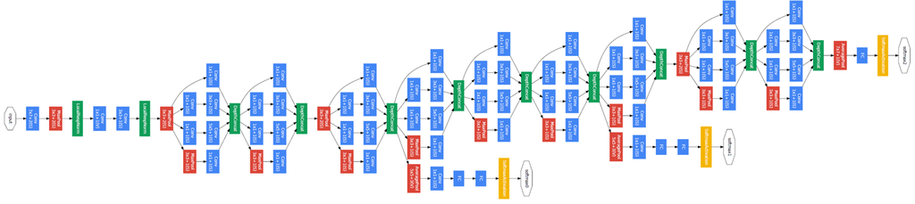

## 1.5. ResNet

- He, Kaiming, et al. "Deep residual learning for image recognition." CVPR. 2016.

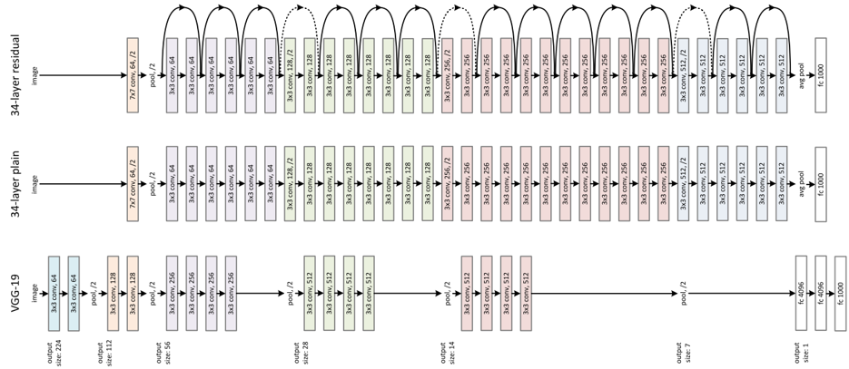

**Skip Connection and Residual Net**

- A direct connection between 2 non-consecutive layers
- No gradient vanishing
- Parameters are optimized to learn a residual, that is the diﬀerence between the value before the block and the one needed after.
- A skip connection is a connection that bypasses at least one layer.
- Here, it is often used to transfer local information by concatenating or summing feature maps from the downsampling path with feature maps from the upsampling path.
- Merging features from various resolution levels helps combining context information with spatial information.

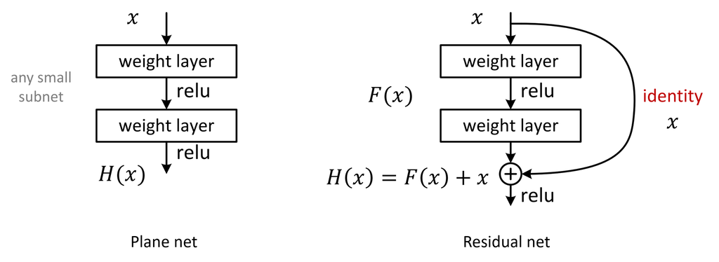

```python
def residual_net(x):
    conv1 = tf.keras.layers.Conv2D(filters = 32,
                                   kernel_size = (3, 3),
                                   padding = "SAME",
                                   activation = 'relu')(x)


    conv2 = tf.keras.layers.Conv2D(filters = 32,
                                   kernel_size = (3, 3),
                                   padding = "SAME",
                                   activation = 'relu')(conv1)

    maxp2 = tf.keras.layers.MaxPool2D(pool_size = (2, 2),
                                      strides = 2)(conv2 + x)

    flat = tf.keras.layers.Flatten()(maxp2)

    hidden = tf.keras.layers.Dense(units = n_hidden,
                                   activation='relu')(flat)

    output = tf.keras.layers.Dense(units = n_output)(hidden)

    return output
```

## 1.6. DenseNets

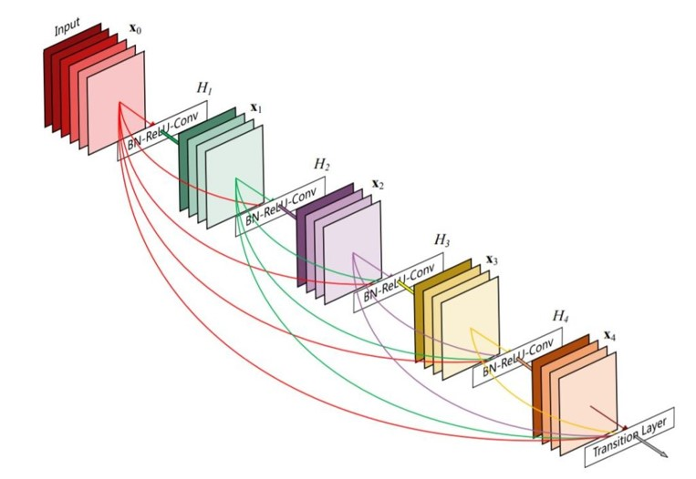

## 1.7 U-Net

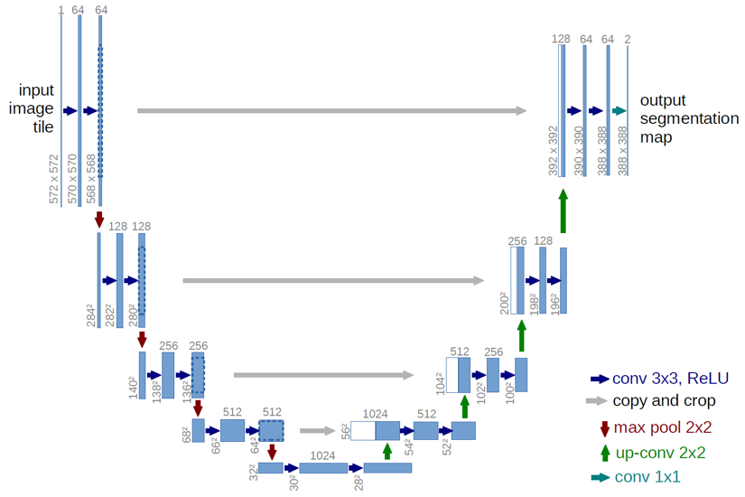

- The U-Net owes its name to its symmetric shape
- The U-Net architecture is built upon the Fully Convolutional Network and modified in a way that it yields better segmentation in medical imaging.
- Compared to FCN-8, the two main differences are
  - U-net is symmetric and
  - the skip connections between the downsampling path and the upsampling path apply a concatenation operator instead of a sum.
- These skip connections intend to provide local information to the global information while upsampling. Because of its symmetry, the network has a large number of feature maps in the upsampling path, which allows to transfer information.

# 2. Load Pre-trained Models

## 2.1. List of Available Models

- VGG16
- VGG19
- ResNet
- GoogLeNet/Inception
- DenseNet
- MobileNet

```python
import tensorflow as tf
import numpy as np
import matplotlib.pyplot as plt
import cv2

%matplotlib inline
```

# 3. Model Selection

```python
# model_type = tf.keras.applications.densenet
# model_type = tf.keras.applications.inception_resnet_v2
# model_type = tf.keras.applications.inception_v3
model_type = tf.keras.applications.mobilenet
# model_type = tf.keras.applications.mobilenet_v2
# model_type = tf.keras.applications.nasnet
# model_type = tf.keras.applications.resnet50
# model_type = tf.keras.applications.vgg16
# model_type = tf.keras.applications.vgg19
```

## 3.1. Model Summary

```python
model = model_type.MobileNet() # Change Model (hint : use capital name)

model.summary()
```

```
Model: "mobilenet_1.00_224"
_________________________________________________________________
Layer (type)                 Output Shape              Param #
=================================================================
input_1 (InputLayer)         [(None, 224, 224, 3)]     0
_________________________________________________________________
conv1 (Conv2D)               (None, 112, 112, 32)      864
_________________________________________________________________
conv1_bn (BatchNormalization (None, 112, 112, 32)      128
_________________________________________________________________
conv1_relu (ReLU)            (None, 112, 112, 32)      0
_________________________________________________________________
conv_dw_1 (DepthwiseConv2D)  (None, 112, 112, 32)      288
_________________________________________________________________
conv_dw_1_bn (BatchNormaliza (None, 112, 112, 32)      128
_________________________________________________________________
conv_dw_1_relu (ReLU)        (None, 112, 112, 32)      0
_________________________________________________________________
conv_pw_1 (Conv2D)           (None, 112, 112, 64)      2048
_________________________________________________________________
conv_pw_1_bn (BatchNormaliza (None, 112, 112, 64)      256
_________________________________________________________________
conv_pw_1_relu (ReLU)        (None, 112, 112, 64)      0
_________________________________________________________________
conv_pad_2 (ZeroPadding2D)   (None, 113, 113, 64)      0
_________________________________________________________________
conv_dw_2 (DepthwiseConv2D)  (None, 56, 56, 64)        576
_________________________________________________________________
conv_dw_2_bn (BatchNormaliza (None, 56, 56, 64)        256
_________________________________________________________________
conv_dw_2_relu (ReLU)        (None, 56, 56, 64)        0
_________________________________________________________________
conv_pw_2 (Conv2D)           (None, 56, 56, 128)       8192
_________________________________________________________________
conv_pw_2_bn (BatchNormaliza (None, 56, 56, 128)       512
_________________________________________________________________
conv_pw_2_relu (ReLU)        (None, 56, 56, 128)       0
_________________________________________________________________
conv_dw_3 (DepthwiseConv2D)  (None, 56, 56, 128)       1152
_________________________________________________________________
```

[output cut: 137 more lines]

```
_________________________________________________________________
reshape_1 (Reshape)          (None, 1, 1, 1024)        0
_________________________________________________________________
dropout (Dropout)            (None, 1, 1, 1024)        0
_________________________________________________________________
conv_preds (Conv2D)          (None, 1, 1, 1000)        1025000
_________________________________________________________________
reshape_2 (Reshape)          (None, 1000)              0
_________________________________________________________________
predictions (Activation)     (None, 1000)              0
=================================================================
Total params: 4,253,864
Trainable params: 4,231,976
Non-trainable params: 21,888
_________________________________________________________________
```

# 4. ImageNet

- Download [image 1](https://www.dropbox.com/s/l4i78sretm9wm67/ILSVRC2017_test_00000005.JPEG?dl=1)
- Download [image 2](https://www.dropbox.com/s/qw4s88kxyjryaio/ILSVRC2017_test_00005381.JPEG?dl=1)

```
(500, 333, 3)
```

[figure not shown]

```python
# img = cv2.imread('.\data_files\ILSVRC2017_test_00000005.JPEG')
img = cv2.imread('.\data_files\ILSVRC2017_test_00005381.JPEG')

print(img.shape)

plt.figure(figsize = (10,8))
plt.imshow(img)
plt.axis('off')
plt.show()
```

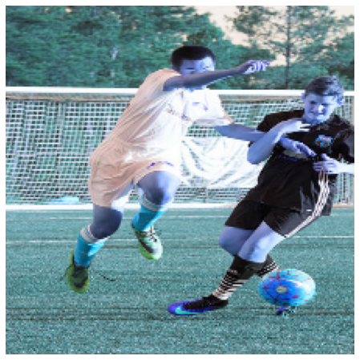

```python
resized_img = cv2.resize(img, (224, 224)).reshape(1, 224, 224, 3)

plt.figure(figsize = (10,8))
plt.imshow(resized_img[0])
plt.axis('off')
plt.show()
```

```python
input_img = model_type.preprocess_input(resized_img)

pred = model.predict(input_img)
label = model_type.decode_predictions(pred)[0]

print('%s (%.2f%%)\n' % (label[0][1], label[0][2]*100))
print('%s (%.2f%%)\n' % (label[1][1], label[1][2]*100))
print('%s (%.2f%%)\n' % (label[2][1], label[2][2]*100))
print('%s (%.2f%%)\n' % (label[3][1], label[3][2]*100))
print('%s (%.2f%%)\n' % (label[4][1], label[4][2]*100))
```

```
soccer_ball (92.07%)

knee_pad (2.68%)

football_helmet (2.44%)

ballplayer (1.17%)

tennis_ball (0.49%)
```

```python
%%javascript
$.getScript('https://kmahelona.github.io/ipython_notebook_goodies/ipython_notebook_toc.js')
```